# FoS_HW_06_Group_II

RNR

2025-11-24

### 1.

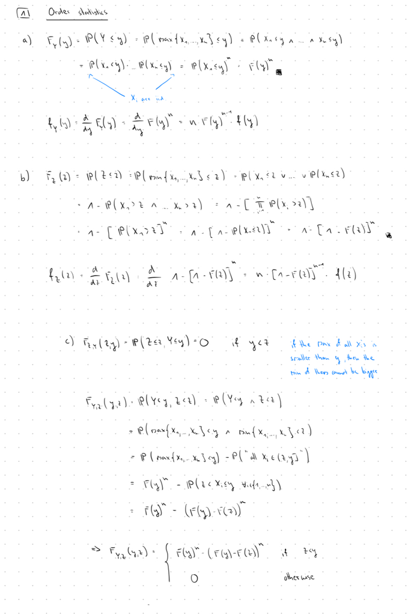

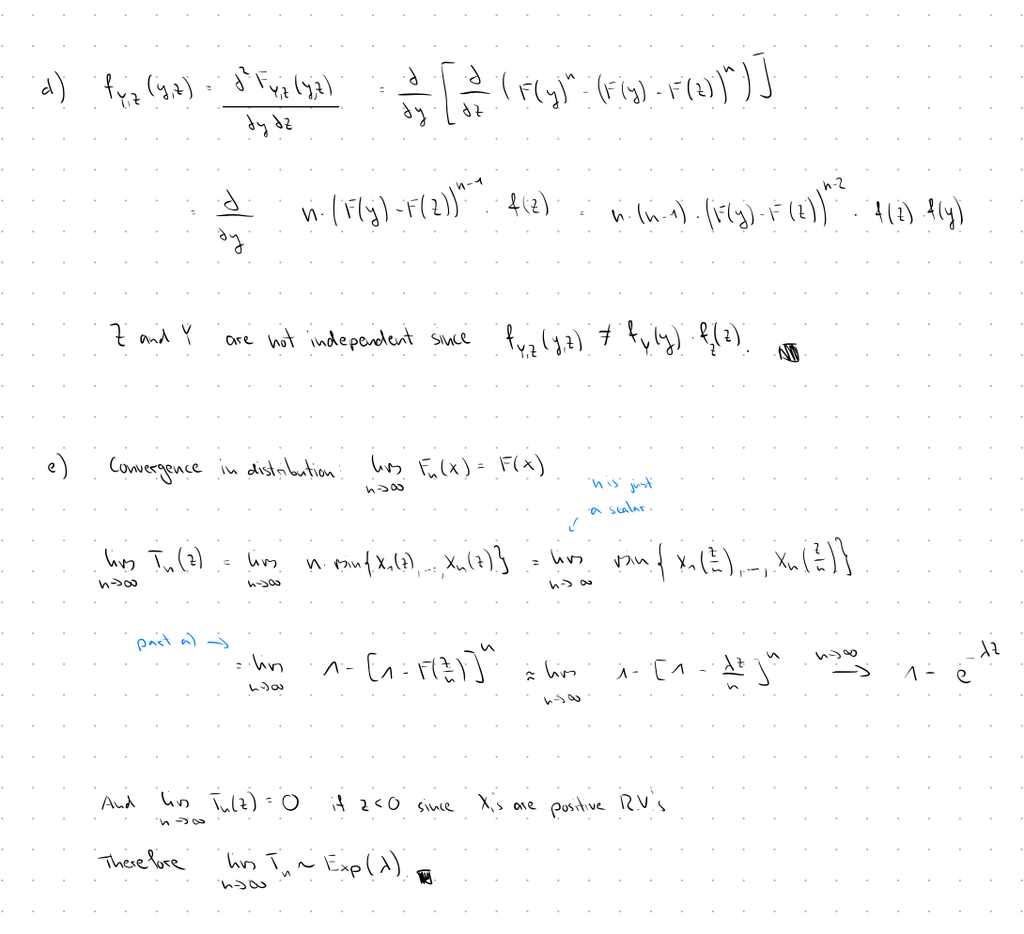

### 2.

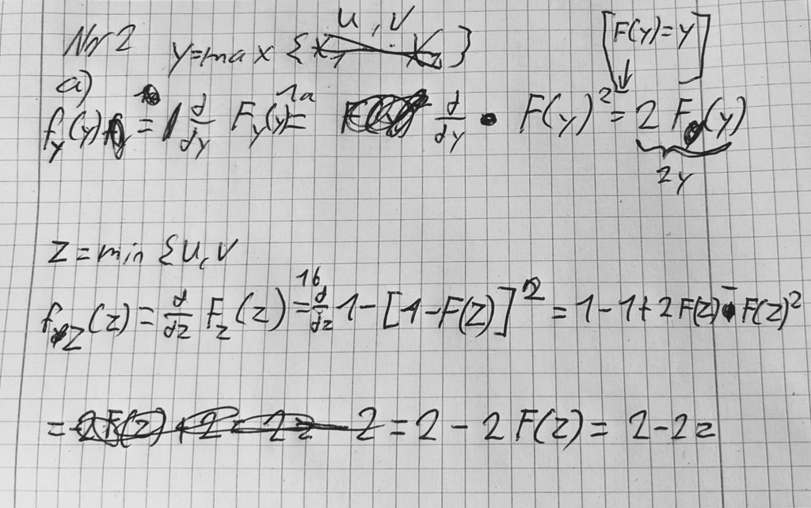

##### code to a

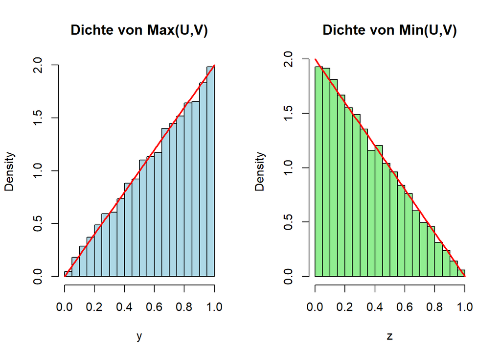

```r
n <- 10000
u <- runif(n)
v <- runif(n)

y_max <- pmax(u, v)
z_min <- pmin(u, v)


par(mfrow=c(1,2))
hist(y_max, freq=FALSE, main="Dichte von Max(U,V)", xlab="y", col="lightblue")
curve(2*x, add=TRUE, col="red", lwd=2)

hist(z_min, freq=FALSE, main="Dichte von Min(U,V)", xlab="z", col="lightgreen")
curve(2-2*x, add=TRUE, col="red", lwd=2)
```

#### b

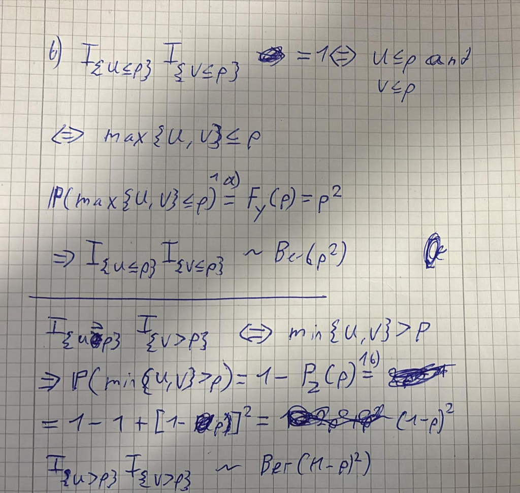

#### c

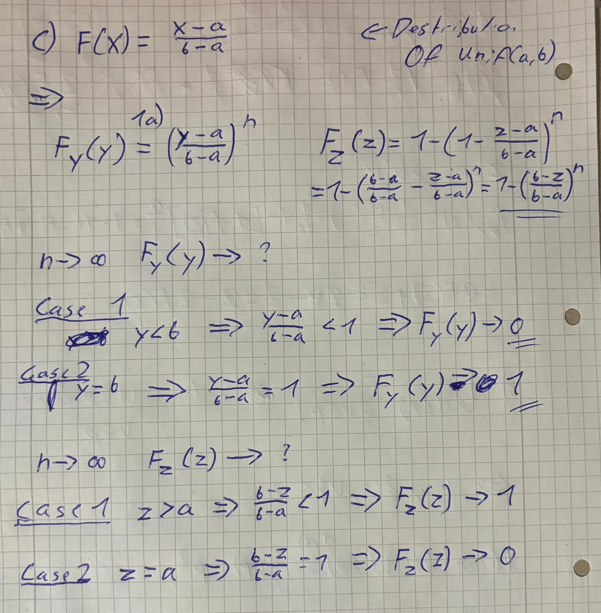

#### d

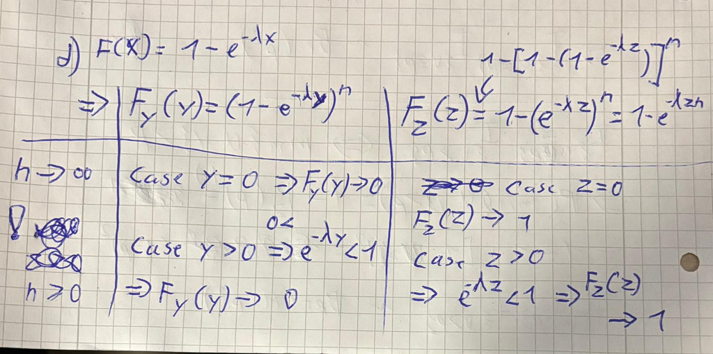

### 3.

#### a)

$$P(|X-\mu| \geq a) \leq
\frac{Var(X)}{a^2}, \forall a >0$$

```r
library("UsingR")
var(exec.pay)/(3*sd(exec.pay))**2
```

```
## [1] 0.1111111
```

#### b)

```r
mu <- mean(exec.pay)
sd <- sd(exec.pay)

lb <- mu - 3*sd
ub <- mu + 3*sd

1-(pnorm(ub, mean = mu, sd = sd)-pnorm(lb, mean = mu, sd = sd))
```

```
## [1] 0.002699796
```

#### c)

$$z_i := \frac{1}{s}(x_i-\bar{x}), i = 1,
... , n$$
$$sz_i = (x_i-\bar{x}), i =
1, ... , n$$
For $z_i = 3$ is the deviation from the mean, three times the standard deviation.

#### d)

```r
# install.packages("UsingR")
# require("UsingR")
summary(exec.pay)
```

```
##    Min. 1st Qu.  Median    Mean 3rd Qu.    Max.
##    0.00   14.00   27.00   59.89   41.50 2510.00
```

```r
head(exec.pay)
```

```
## [1] 136  74   8  38  46  43
```

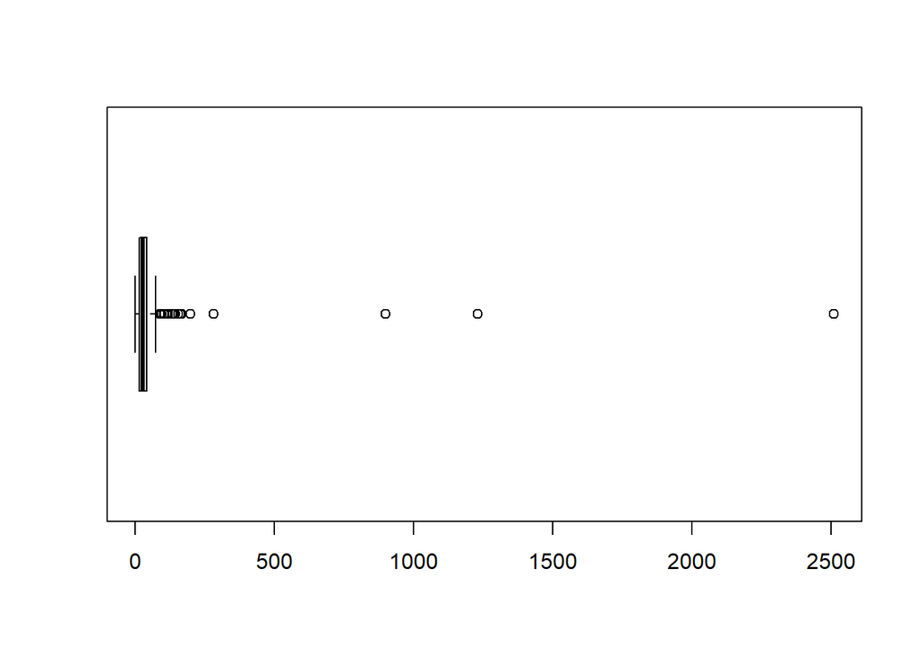

```r
boxplot(exec.pay, horizontal = TRUE)
```

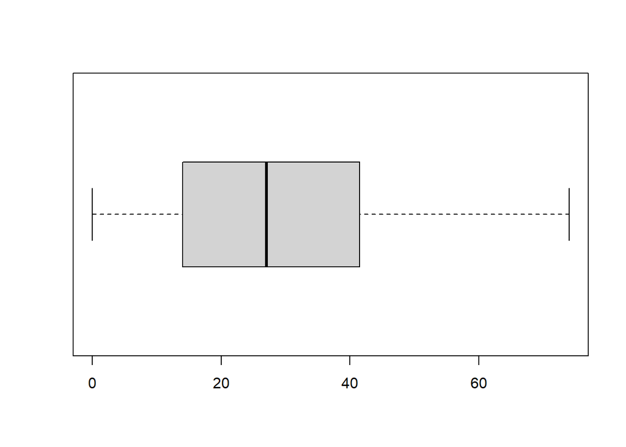

```r
boxplot(exec.pay, horizontal = TRUE, outline = FALSE)
```

From the second boxplot it is clear that the outliers are after the second whisker(about 76).

#### e)

```r
mean <- mean(exec.pay)
sd <- sd(exec.pay)
z_score <- (exec.pay-mean)/sd
z_score   # or just < - scale(exec.pay)
```

[output not shown]

[output cut: 25 more lines]

```r
propb_3sd <- mean(abs(z_score) > 3)
propb_3sd
```

```
## [1] 0.01507538
```

```r
cat("Comparison: normal distribution 0.27% < z-score 1.51% << Chebyshevs inequality 11%")
```

```
## Comparison: normal distribution 0.27% < z-score 1.51% << Chebyshevs inequality 11%
```

#### f)

**definition of z-score**

$$z_i = \frac{1}{s}(x_i -
\bar{x})$$

where $s$ is the sample standard deviation with denominator $n$:

$$s = \sqrt{\frac{1}{n}\sum_{i=1}^{n}(x_i
- \bar{x})^2}$$

From the z-score definition:
$$x_i -
\bar{x} = s \cdot z_i$$

**Substitute into the numerator**

$$\sum_{i=1}^{n}(x_i - \bar{x})^3 =
\sum_{i=1}^{n}(s \cdot z_i)^3 = s^3 \sum_{i=1}^{n}z_i^3$$

**Substitute into the denominator**

$$\sum_{i=1}^{n}(x_i - \bar{x})^2 =
\sum_{i=1}^{n}(s \cdot z_i)^2 = s^2 \sum_{i=1}^{n}z_i^2$$

Since $s^2 = \frac{1}{n}\sum_{i=1}^{n}(x_i - \bar{x})^2$, we have:

$$\sum_{i=1}^{n}(x_i - \bar{x})^2 =
ns^2$$

Therefore:
$$s^2 \sum_{i=1}^{n}z_i^2 =
ns^2$$

This implies:
$$\sum_{i=1}^{n}z_i^2 =
n$$

**Simplify the denominator term**

$$\left[\sum_{i=1}^{n}(x_i -
\bar{x})^2\right]^{3/2} = \left[s^2 \sum_{i=1}^{n}z_i^2\right]^{3/2} =
[s^2 \cdot n]^{3/2} = s^3 \cdot n^{3/2}$$

**everything combined**

$$\sqrt{n} \cdot \frac{\sum_{i=1}^{n}(x_i
- \bar{x})^3}{\left[\sum_{i=1}^{n}(x_i - \bar{x})^2\right]^{3/2}} =
\sqrt{n} \cdot \frac{s^3 \sum_{i=1}^{n}z_i^3}{s^3 \cdot
n^{3/2}}$$

$$= \sqrt{n} \cdot
\frac{\sum_{i=1}^{n}z_i^3}{n^{3/2}} = \frac{n^\frac{1}{2}}{n^{3/2}}
\sum_{i=1}^{n}z_i^3$$

$$= \frac{1}{n}
\sum_{i=1}^{n}z_i^3$$

#### g)

From f);

```r
sum(z_score**3)/length(z_score)
```

```
## [1] 9.578542
```

#### h)

**definition of z-score**

$$z_i = \frac{1}{s}(x_i -
\bar{x})$$

where $s$ is the sample standard deviation with denominator $n$:

$$s = \sqrt{\frac{1}{n}\sum_{i=1}^{n}(x_i
- \bar{x})^2}$$

From the z-score definition:
$$x_i -
\bar{x} = s \cdot z_i$$

**Substitute into the numerator**

$$\sum_{i=1}^{n}(x_i - \bar{x})^4 =
\sum_{i=1}^{n}(s \cdot z_i)^4 = s^4 \sum_{i=1}^{n}z_i^4$$

**Substitute into the denominator**

$$\sum_{i=1}^{n}(x_i - \bar{x})^2 =
\sum_{i=1}^{n}(s \cdot z_i)^2 = s^2 \sum_{i=1}^{n}z_i^2$$

**Recall from f) that $\sum_{i=1}^{n}z_i^2 = n$**

**Simplify the denominator term**

$$\left[\sum_{i=1}^{n}(x_i -
\bar{x})^2\right]^2 = \left[s^2 \sum_{i=1}^{n}z_i^2\right]^2 = [s^2
\cdot n]^2 = s^4 \cdot n^2$$

**everything combined**

$$n \cdot \frac{\sum_{i=1}^{n}(x_i -
\bar{x})^4}{\left[\sum_{i=1}^{n}(x_i - \bar{x})^2\right]^2} - 3 = n
\cdot \frac{s^4 \sum_{i=1}^{n}z_i^4}{s^4 \cdot n^2} - 3$$

$$= n \cdot
\frac{\sum_{i=1}^{n}z_i^4}{n^2} - 3 = \frac{1}{n}\sum_{i=1}^{n}z_i^4 -
3$$

**Why subtract 3?**

The subtraction of 3 is a normalization convention. For a standard normal distribution, the fourth moment $E[Z^4] = 3$ (since for $Z \sim N(0,1)$, we have $E[Z^4] = 3 \cdot (E[Z^2])^2 = 3 \cdot 1^2 = 3$).

By subtracting 3, we get:

- **Kurtosis = 0** for normal distributions (mesokurtic)
- **Kurtosis > 0** for distributions with heavy tails (leptokurtic)
- **Kurtosis < 0** for distributions with light tails (platykurtic)

#### i)

From g);

```r
sum(z_score**4-3)/length(z_score)
```

```
## [1] 102.064
```

```r
#(sum(z_score**4)-3*length(z_score))/length(z_score)
```

### 4.

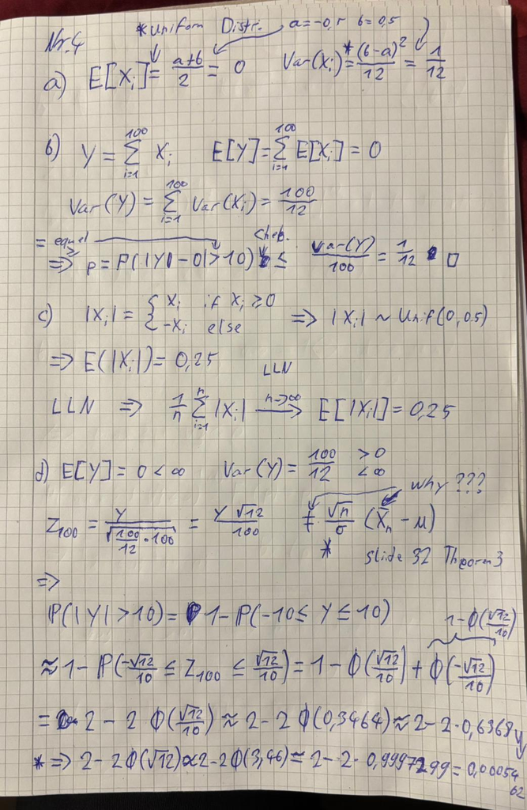

### 5.

In this exercise we just have to modify the code from the lecture slides

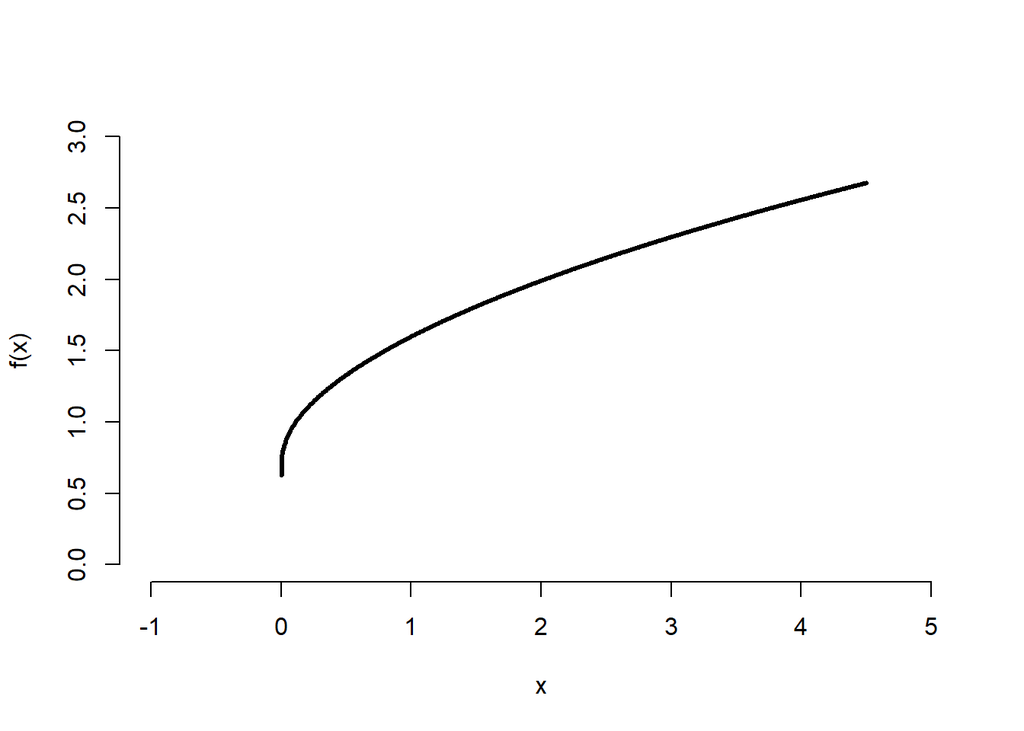

```r
n <- 10e4
f<-function(x){sqrt(x+sqrt(x+sqrt(x+sqrt(x))))}
x<-seq(-0.5,4.5,length=1000)
plot(x,f(x),type="l",xlim=c(-1,5), ylim=c(0,3),bty="n",lwd=3)
```

```r
h<-0 # absolute frequency of getting points under the curve f
for (i in 1:n){
  x<-runif(1,0,4)
  y<-runif(1,0,4)
  if (y<f(x)){
    h<-h+1
  }
  else {
  }
}

16*h/n # approximation of the grey area
```

```
## [1] 7.67408
```